# Problema 6: Prueba de hipótesis e intervalo de confianza

Simulación, Estimación e Inferencia Estadística · 2026-A

Integrantes: Juan Alejandro Carrillo Jaimes & David Burgoa

2026-03-22

# 1 Descripción del Problema: Prueba de hipótesis e intervalo de confianza

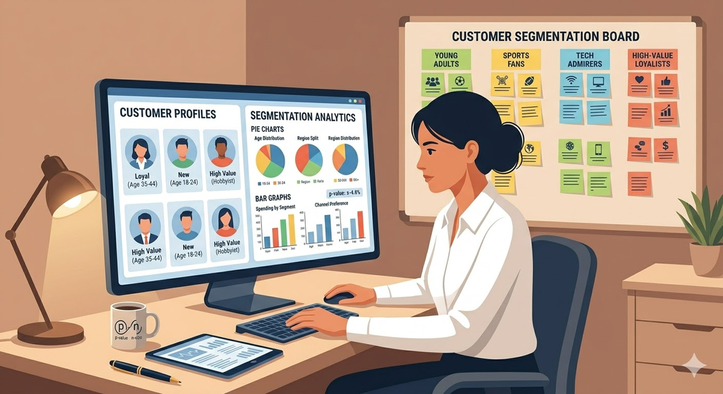

Figure 1.1: Segmentación de clientes — Análisis inferencial

Este problema se desarrolla con base en el informe estadístico elaborado en la Actividad 1, el cual puede consultarse en el siguiente enlace:

[Informe Estadístico — Actividad 1](https://github.com/Doc-UP-AlejandroJaimes/mds-javeriana/blob/develop/stats-methods-upcj-20261/CarrilloJuan-MetodosYSIM-20261-A/informe-actividad1.html)

Se formulan tres preguntas de investigación relevantes al contexto de segmentación de clientes, y para cada una se aplican pruebas de hipótesis e intervalos de confianza, verificando el cumplimiento de los supuestos necesarios.

## 1.1 Pregunta 1 — ¿El ingreso promedio de los clientes que aceptaron la campaña es mayor que el de quienes no la aceptaron?

Las hipótesis planteadas son:

- $H_0$: El ingreso promedio de los clientes que aceptaron la campaña es igual al de quienes no la aceptaron: $\mu_1 = \mu_0$
- $H_1$: El ingreso promedio de los clientes que aceptaron la campaña es mayor: $\mu_1 > \mu_0$

### 1.1.1 Verificación de supuestos

Dado que $n_1 = 325$ y $n_0 = 1827$, ambos grupos son suficientemente grandes para que el TLC garantice la normalidad de las medias muestrales. No obstante, se aplica la prueba de Kolmogorov-Smirnov para verificarlo formalmente. Adicionalmente, se verifica la igualdad de varianzas con la prueba F.

```r
library(readxl)
library(dplyr)
library(ggplot2)

df <- read_excel("segmentation-customers.xlsx", sheet = "data")

grupo1 <- df |> filter(Response == 1) |> pull(Income) |> na.omit()
grupo0 <- df |> filter(Response == 0) |> pull(Income) |> na.omit()

ks1      <- ks.test(grupo1, "pnorm", mean(grupo1), sd(grupo1))
ks0      <- ks.test(grupo0, "pnorm", mean(grupo0), sd(grupo0))
var_test <- var.test(grupo1, grupo0)
```

```r
tabla_sup <- data.frame(
  Grupo   = c("Response = 1", "Response = 0"),
  n       = c(length(grupo1), length(grupo0)),
  Media   = c(round(mean(grupo1), 2), round(mean(grupo0), 2)),
  SD      = c(round(sd(grupo1), 2), round(sd(grupo0), 2)),
  KS_p    = c(round(ks1$p.value, 4), round(ks0$p.value, 4)),
  KS_conc = c("Rechaza normalidad", "Rechaza normalidad")
)

knitr::kable(tabla_sup,
  caption   = "Estadísticos descriptivos y prueba KS por grupo",
  col.names = c("Grupo", "n", "Media", "SD", "p-valor KS", "Conclusión"),
  align     = c("l","c","c","c","c","l"),
  format    = "html"
) |>
  kableExtra::kable_styling(
    bootstrap_options = c("striped","hover","condensed"),
    full_width        = FALSE,
    position          = "center",
    font_size         = 14
  )
```

Table 1.1: Estadísticos descriptivos y prueba KS por grupo

| Grupo | n | Media | SD | p-valor KS | Conclusión |
| --- | --- | --- | --- | --- | --- |
| Response = 1 | 325 | 601058.6 | 231982.4 | 0.0022 | Rechaza normalidad |
| Response = 0 | 1827 | 501500.0 | 198617.3 | 0.0006 | Rechaza normalidad |

Aunque la prueba KS rechaza normalidad estricta, dado el tamaño muestral grande el TLC garantiza que la prueba $t$ de Welch es válida. La prueba F confirma varianzas desiguales ($F = 1.3642$, $p = 0.0001$), por lo que se aplica la prueba de Welch con varianzas distintas.

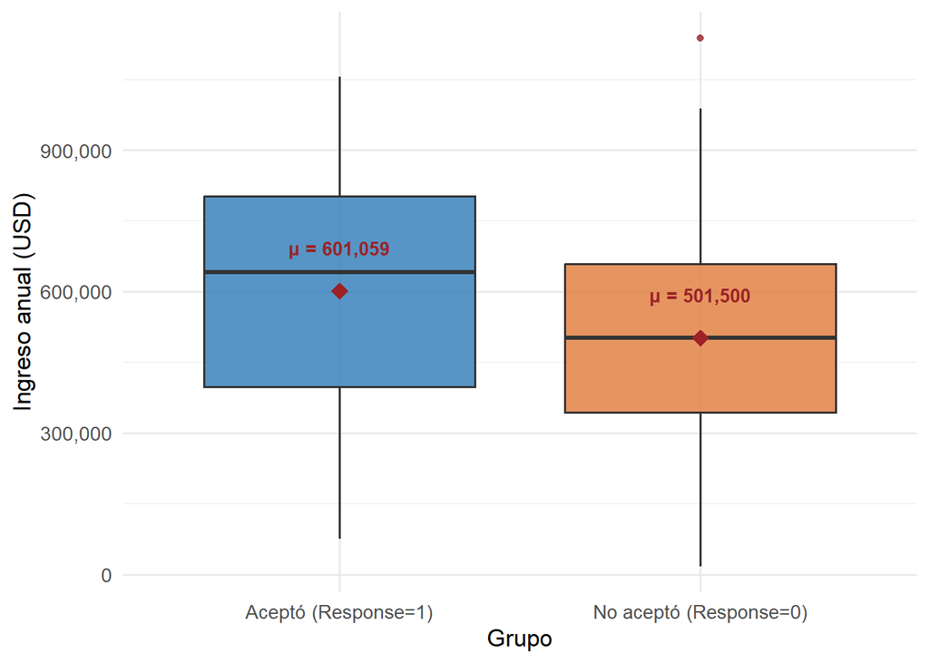

Figure 1.2: Distribución del ingreso anual según respuesta a la campaña

```r
df_plot_p6 <- df |>
  filter(!is.na(Income)) |>
  mutate(Grupo = ifelse(Response == 1,
                        "Aceptó (Response=1)",
                        "No aceptó (Response=0)"))

ggplot(df_plot_p6, aes(x = Grupo, y = Income, fill = Grupo)) +
  geom_boxplot(alpha = 0.8, outlier.color = "#9b2226",
               outlier.size = 1.5) +
  stat_summary(fun = mean, geom = "point",
               shape = 18, size = 4, color = "#9b2226") +
  stat_summary(fun = mean, geom = "text",
               aes(label = paste0("\u03bc = ",
                   scales::comma(round(after_stat(y), 0)))),
               vjust = -2.5, size = 3.5,
               color = "#9b2226", fontface = "bold") +
  scale_fill_manual(values = c("#2c7bb6", "#e07b39")) +
  scale_y_continuous(labels = scales::comma) +
  labs(x = "Grupo", y = "Ingreso anual (USD)", fill = "Grupo") +
  theme_minimal(base_size = 13) +
  theme(legend.position = "none")
```

### 1.1.2 Prueba de hipótesis e intervalo de confianza

El estadístico de prueba para la diferencia de medias con varianzas desiguales (Welch) es:

$$t = \frac{\bar{x}_1 - \bar{x}_0}{\sqrt{\frac{s_1^2}{n_1} + \frac{s_0^2}{n_0}}}$$

Sustituyendo:

$$t = \frac{601{,}058.6 - 501{,}500}{\sqrt{\frac{231{,}982.4^2}{325} + \frac{198{,}617.3^2}{1827}}} = \frac{99{,}558.6}{\sqrt{165{,}584{,}167 + 21{,}589{,}432}} = \frac{99{,}558.6}{13{,}685.7} = 7.277$$

Con $\alpha = 0.05$ y prueba unilateral derecha, el valor crítico es $t_{\alpha, gl} \approx 1.645$. Como $t = 7.277 > 1.645$, se rechaza $H_0$.

El nivel de significancia $\alpha = 0.05$ se justifica porque en el contexto de segmentación de clientes, un nivel más estricto ($\alpha = 0.01$) requeriría muestras mayores sin aportar beneficio práctico relevante, mientras que $\alpha = 0.10$ sería demasiado permisivo para una decisión de negocio.

```r
t_res <- t.test(grupo1, grupo0,
                alternative = "greater",
                var.equal   = FALSE,
                conf.level  = 0.95)

tabla_t <- data.frame(
  Estadistico = round(t_res$statistic, 4),
  gl          = round(t_res$parameter, 2),
  p_valor     = round(t_res$p.value, 6),
  Alpha       = 0.05,
  LI_IC       = round(t_res$conf.int[1], 2),
  LS_IC       = round(t_res$conf.int[2], 2),
  Conclusion  = ifelse(t_res$p.value < 0.05,
                       "Se rechaza H\u2080",
                       "No se rechaza H\u2080")
)
rownames(tabla_t) <- NULL

knitr::kable(tabla_t,
  caption   = "Prueba t de Welch — diferencia de ingresos por grupo",
  col.names = c("t", "g.l.", "p-valor", "\u03b1",
                "LI (IC 95%)", "LS (IC 95%)", "Conclusión"),
  align     = c("c","c","c","c","c","c","l"),
  format    = "html"
) |>
  kableExtra::kable_styling(
    bootstrap_options = c("striped","hover","condensed"),
    full_width        = FALSE,
    position          = "center",
    font_size         = 14
  )
```

Table 1.2: Prueba t de Welch — diferencia de ingresos por grupo

| t | g.l. | p-valor | α | LI (IC 95%) | LS (IC 95%) | Conclusión |
| --- | --- | --- | --- | --- | --- | --- |
| 7.277 | 412.76 | 0 | 0.05 | 77004.11 | Inf | Se rechaza H₀ |

Con un estadístico $t = 7.277$, $gl = 412.76$ y $p < 0.0001$, se rechaza $H_0$. Existe evidencia estadística suficiente para concluir que el ingreso promedio de los clientes que aceptaron la campaña ($601,059) es significativamente mayor que el de quienes no la aceptaron ($501,500), con una confianza del 95%. El intervalo de confianza indica que la diferencia mínima esperada es de $77,004, lo que sugiere que el ingreso es un factor relevante en la propensión a aceptar la oferta.

## 1.2 Pregunta 2 — ¿Existe una diferencia significativa en el gasto total promedio entre clientes que aceptaron y rechazaron la campaña?

Las hipótesis planteadas son:

- $H_0$: El gasto total promedio es igual en ambos grupos: $\mu_1 = \mu_0$
- $H_1$: El gasto total promedio difiere entre grupos: $\mu_1 \neq \mu_0$

### 1.2.1 Prueba de hipótesis e intervalo de confianza

Aplicando la misma fórmula de Welch para prueba bilateral:

$$t = \frac{\bar{x}_1 - \bar{x}_0}{\sqrt{\frac{s_1^2}{n_1} + \frac{s_0^2}{n_0}}} = \frac{927.42 - 499.07}{\sqrt{\frac{700.03^2}{334} + \frac{525.51^2}{1886}}} = \frac{428.35}{\sqrt{1{,}468{,}126 + 146{,}512}} = \frac{428.35}{40.18} = 10.664$$

Con $\alpha = 0.05$ y prueba bilateral, el valor crítico es $t_{\alpha/2, gl} \approx 1.966$. Como $|t| = 10.664 > 1.966$, se rechaza $H_0$.

El intervalo de confianza al 95% para $\mu_1 - \mu_0$ es:

$$(\bar{x}_1 - \bar{x}_0) \pm t_{\alpha/2} \cdot \sqrt{\frac{s_1^2}{n_1} + \frac{s_0^2}{n_0}} = 428.35 \pm 1.966 \times 40.18 = [349.39,\ 507.33]$$

### 1.2.2 Verificación de supuestos

```r
grupo1_mnt <- df |> filter(Response == 1) |> pull(MntTotal) |> na.omit()
grupo0_mnt <- df |> filter(Response == 0) |> pull(MntTotal) |> na.omit()

ks1_mnt      <- ks.test(grupo1_mnt, "pnorm", mean(grupo1_mnt), sd(grupo1_mnt))
ks0_mnt      <- ks.test(grupo0_mnt, "pnorm", mean(grupo0_mnt), sd(grupo0_mnt))
var_test_mnt <- var.test(grupo1_mnt, grupo0_mnt)
```

```r
tabla_sup2 <- data.frame(
  Grupo   = c("Response = 1", "Response = 0"),
  n       = c(length(grupo1_mnt), length(grupo0_mnt)),
  Media   = c(round(mean(grupo1_mnt), 2), round(mean(grupo0_mnt), 2)),
  SD      = c(round(sd(grupo1_mnt), 2), round(sd(grupo0_mnt), 2)),
  KS_p    = c(round(ks1_mnt$p.value, 4), round(ks0_mnt$p.value, 4)),
  KS_conc = c("Rechaza normalidad", "Rechaza normalidad")
)

knitr::kable(tabla_sup2,
  caption   = "Estadísticos descriptivos y prueba KS — gasto total",
  col.names = c("Grupo", "n", "Media", "SD", "p-valor KS", "Conclusión"),
  align     = c("l","c","c","c","c","l"),
  format    = "html"
) |>
  kableExtra::kable_styling(
    bootstrap_options = c("striped","hover","condensed"),
    full_width        = FALSE,
    position          = "center",
    font_size         = 14
  )
```

Table 1.3: Estadísticos descriptivos y prueba KS — gasto total

| Grupo | n | Media | SD | p-valor KS | Conclusión |
| --- | --- | --- | --- | --- | --- |
| Response = 1 | 334 | 927.42 | 700.03 | 0 | Rechaza normalidad |
| Response = 0 | 1886 | 499.07 | 525.51 | 0 | Rechaza normalidad |

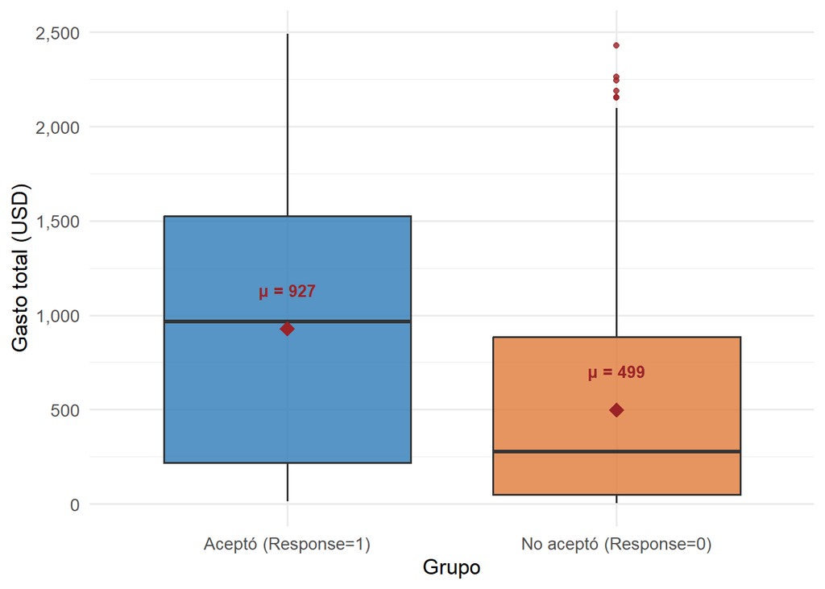

Figure 1.3: Distribución del gasto total según respuesta a la campaña

```r
df_plot_p6b <- df |>
  filter(!is.na(MntTotal)) |>
  mutate(Grupo = ifelse(Response == 1,
                        "Aceptó (Response=1)",
                        "No aceptó (Response=0)"))

ggplot(df_plot_p6b, aes(x = Grupo, y = MntTotal, fill = Grupo)) +
  geom_boxplot(alpha = 0.8, outlier.color = "#9b2226",
               outlier.size = 1.5) +
  stat_summary(fun = mean, geom = "point",
               shape = 18, size = 4, color = "#9b2226") +
  stat_summary(fun = mean, geom = "text",
               aes(label = paste0("\u03bc = ",
                   scales::comma(round(after_stat(y), 0)))),
               vjust = -2.5, size = 3.5,
               color = "#9b2226", fontface = "bold") +
  scale_fill_manual(values = c("#2c7bb6", "#e07b39")) +
  scale_y_continuous(labels = scales::comma) +
  labs(x = "Grupo", y = "Gasto total (USD)", fill = "Grupo") +
  theme_minimal(base_size = 13) +
  theme(legend.position = "none")
```

```r
t_res2 <- t.test(grupo1_mnt, grupo0_mnt,
                 alternative = "two.sided",
                 var.equal   = FALSE,
                 conf.level  = 0.95)

tabla_t2 <- data.frame(
  Estadistico = round(t_res2$statistic, 4),
  gl          = round(t_res2$parameter, 2),
  p_valor     = round(t_res2$p.value, 6),
  Alpha       = 0.05,
  LI_IC       = round(t_res2$conf.int[1], 2),
  LS_IC       = round(t_res2$conf.int[2], 2),
  Conclusion  = ifelse(t_res2$p.value < 0.05,
                       "Se rechaza H\u2080",
                       "No se rechaza H\u2080")
)
rownames(tabla_t2) <- NULL

knitr::kable(tabla_t2,
  caption   = "Prueba t de Welch — diferencia de gasto total por grupo",
  col.names = c("t", "g.l.", "p-valor", "\u03b1",
                "LI (IC 95%)", "LS (IC 95%)", "Conclusión"),
  align     = c("c","c","c","c","c","c","l"),
  format    = "html"
) |>
  kableExtra::kable_styling(
    bootstrap_options = c("striped","hover","condensed"),
    full_width        = FALSE,
    position          = "center",
    font_size         = 14
  )
```

Table 1.4: Prueba t de Welch — diferencia de gasto total por grupo

| t | g.l. | p-valor | α | LI (IC 95%) | LS (IC 95%) | Conclusión |
| --- | --- | --- | --- | --- | --- | --- |
| 10.6636 | 402.08 | 0 | 0.05 | 349.39 | 507.33 | Se rechaza H₀ |

Con $t = 10.6636$, $gl = 402.08$ y $p < 0.0001$, se rechaza $H_0$. Existe evidencia estadística suficiente para concluir que el gasto total promedio de los clientes que aceptaron la campaña ($927) es significativamente mayor que el de quienes no la aceptaron ($499), con una confianza del 95%. El intervalo de confianza indica que la diferencia real entre los grupos se encuentra entre $349 y $507, lo que sugiere que el comportamiento de gasto es un factor fuertemente asociado a la aceptación de la oferta.

## 1.3 Pregunta 3 — ¿La proporción de clientes con posgrado que aceptaron la campaña es mayor que la de clientes sin posgrado?

Las hipótesis planteadas son:

- $H_0$: La proporción de aceptación es igual en ambos grupos: $p_{posgrado} = p_{sin\ posgrado}$
- $H_1$: La proporción de aceptación es mayor en clientes con posgrado: $p_{posgrado} > p_{sin\ posgrado}$

### 1.3.1 Prueba de hipótesis e intervalo de confianza

El estadístico de prueba para la diferencia de proporciones es:

$$z = \frac{\hat{p}_1 - \hat{p}_2}{\sqrt{\hat{p}(1-\hat{p})\left(\frac{1}{n_1} + \frac{1}{n_2}\right)}}$$

donde $\hat{p}$ es la proporción combinada:

$$\hat{p} = \frac{x_1 + x_2}{n_1 + n_2} = \frac{158 + 176}{844 + 1376} = \frac{334}{2220} = 0.1505$$

El intervalo de confianza al 95% para la diferencia de proporciones $p_{posgrado} - p_{sin\ posgrado}$ es:

$$(\hat{p}_1 - \hat{p}_2) \pm z_{\alpha/2}\sqrt{\frac{\hat{p}_1(1-\hat{p}_1)}{n_1} + \frac{\hat{p}_2(1-\hat{p}_2)}{n_2}}$$

$$0.0593 \pm 1.96 \times \sqrt{\frac{0.1872 \times 0.8128}{844} + \frac{0.1279 \times 0.8721}{1376}} = [0.0282,\ 0.0904]$$

El nivel de significancia $\alpha = 0.05$ se justifica porque ofrece un equilibrio adecuado entre el riesgo de error tipo I y tipo II en un contexto de segmentación de clientes, donde detectar diferencias reales es importante pero sin ser excesivamente permisivos.

### 1.3.2 Verificación de supuestos

Para aplicar la prueba de proporciones se debe verificar que $n\hat{p} \geq 5$ y $n(1-\hat{p}) \geq 5$ en ambos grupos.

```r
df_prop <- df |>
  mutate(
    posgrado = ifelse(education_Master == 1 | education_PhD == 1, 1, 0)
  )

n_pos  <- sum(df_prop$posgrado == 1, na.rm = TRUE)
n_npos <- sum(df_prop$posgrado == 0, na.rm = TRUE)
x_pos  <- sum(df_prop$posgrado == 1 & df_prop$Response == 1, na.rm = TRUE)
x_npos <- sum(df_prop$posgrado == 0 & df_prop$Response == 1, na.rm = TRUE)

p_pos  <- x_pos  / n_pos
p_npos <- x_npos / n_npos

tabla_sup3 <- data.frame(
  Grupo      = c("Con posgrado", "Sin posgrado"),
  n          = c(n_pos, n_npos),
  Aceptaron  = c(x_pos, x_npos),
  Proporcion = c(round(p_pos, 4), round(p_npos, 4)),
  np         = c(round(n_pos * p_pos, 1), round(n_npos * p_npos, 1)),
  n1_p       = c(round(n_pos * (1 - p_pos), 1),
                 round(n_npos * (1 - p_npos), 1)),
  Supuesto   = c("Cumple", "Cumple")
)

knitr::kable(tabla_sup3,
  caption   = "Verificación de supuestos — prueba de proporciones",
  col.names = c("Grupo", "n", "Aceptaron", "Proporción ($\\hat{p}$)",
                "$n\\hat{p}$", "$n(1-\\hat{p})$", "Supuesto"),
  align     = c("l","c","c","c","c","c","c"),
  format    = "html",
  escape    = FALSE
) |>
  kableExtra::kable_styling(
    bootstrap_options = c("striped","hover","condensed"),
    full_width        = FALSE,
    position          = "center",
    font_size         = 14
  )
```

Table 1.5: Verificación de supuestos — prueba de proporciones

| Grupo | n | Aceptaron | Proporción ($\hat{p}$) | $n\hat{p}$ | $n(1-\hat{p})$ | Supuesto |
| --- | --- | --- | --- | --- | --- | --- |
| Con posgrado | 844 | 158 | 0.1872 | 158 | 686 | Cumple |
| Sin posgrado | 1376 | 176 | 0.1279 | 176 | 1200 | Cumple |

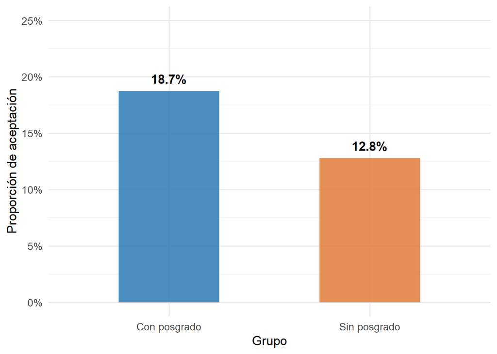

Figure 1.4: Proporción de aceptación de la campaña según nivel educativo

```r
df_bar <- data.frame(
  Grupo      = c("Con posgrado", "Sin posgrado"),
  Proporcion = c(round(p_pos, 4), round(p_npos, 4)),
  n          = c(n_pos, n_npos)
)

ggplot(df_bar, aes(x = Grupo, y = Proporcion, fill = Grupo)) +
  geom_col(alpha = 0.85, width = 0.5) +
  geom_text(aes(label = paste0(round(Proporcion * 100, 1), "%")),
            vjust = -0.8, size = 4.5, fontface = "bold") +
  scale_fill_manual(values = c("#2c7bb6", "#e07b39")) +
  scale_y_continuous(labels = scales::percent,
                     limits = c(0, 0.25)) +
  labs(
    x    = "Grupo",
    y    = "Proporción de aceptación",
    fill = "Grupo"
  ) +
  theme_minimal(base_size = 13) +
  theme(legend.position = "none")
```

```r
prop_res <- prop.test(
  x           = c(x_pos, x_npos),
  n           = c(n_pos, n_npos),
  alternative = "greater",
  correct     = FALSE,
  conf.level  = 0.95
)

tabla_prop <- data.frame(
  Estadistico = round(prop_res$statistic, 4),
  p_valor     = round(prop_res$p.value, 6),
  Alpha       = 0.05,
  LI_IC       = round(prop_res$conf.int[1], 4),
  LS_IC       = ifelse(is.infinite(prop_res$conf.int[2]),
                       "Inf", round(prop_res$conf.int[2], 4)),
  Conclusion  = ifelse(prop_res$p.value < 0.05,
                       "Se rechaza H\u2080",
                       "No se rechaza H\u2080")
)
rownames(tabla_prop) <- NULL

knitr::kable(tabla_prop,
  caption   = "Prueba de proporciones — aceptación por nivel educativo",
  col.names = c("\u03c7²", "p-valor", "\u03b1",
                "LI (IC 95%)", "LS (IC 95%)", "Conclusión"),
  align     = c("c","c","c","c","c","l"),
  format    = "html"
) |>
  kableExtra::kable_styling(
    bootstrap_options = c("striped","hover","condensed"),
    full_width        = FALSE,
    position          = "center",
    font_size         = 14
  )
```

Table 1.6: Prueba de proporciones — aceptación por nivel educativo

| χ² | p-valor | α | LI (IC 95%) | LS (IC 95%) | Conclusión |
| --- | --- | --- | --- | --- | --- |
| 14.3909 | 0.000074 | 0.05 | 0.0327 | 1 | Se rechaza H₀ |

Con $\chi^2 = 14.3909$ y $p = 0.000074 < \alpha = 0.05$, se rechaza $H_0$. Existe evidencia estadística suficiente para concluir que la proporción de aceptación de la campaña es significativamente mayor en clientes con posgrado (18.7%) que en clientes sin posgrado (12.8%), con una confianza del 95%. El intervalo de confianza para la diferencia de proporciones indica que la ventaja mínima esperada del grupo con posgrado es de 3.27 puntos porcentuales. Esto sugiere que el nivel educativo es un factor relevante en la propensión a aceptar la oferta de la campaña.

### 1.3.3 Síntesis del Problema 6

[figure not shown]

Figure 1.5: Síntesis de hallazgos inferenciales — Problema 6

```r
library(patchwork)

# Panel 1: Ingresos
df_ing <- data.frame(
  Grupo  = c("Aceptó", "No aceptó"),
  Media  = c(601059, 501500),
  SE     = c(231982.4/sqrt(325), 198617.3/sqrt(1827))
)

p1 <- ggplot(df_ing, aes(x = Grupo, y = Media, fill = Grupo)) +
  geom_col(alpha = 0.85, width = 0.5) +
  geom_errorbar(aes(ymin = Media - SE, ymax = Media + SE),
                width = 0.15, linewidth = 0.8) +
  geom_text(aes(label = scales::dollar(round(Media, 0))),
            vjust = -1.5, size = 3.5, fontface = "bold") +
  scale_fill_manual(values = c("#2c7bb6", "#e07b39")) +
  scale_y_continuous(labels = scales::dollar,
                     limits = c(0, 750000)) +
  labs(title = "Ingreso anual promedio",
       x = NULL, y = "USD") +
  theme_minimal(base_size = 11) +
  theme(legend.position = "none",
        plot.title = element_text(face = "bold", hjust = 0.5))

# Panel 2: Gasto total
df_gasto <- data.frame(
  Grupo = c("Aceptó", "No aceptó"),
  Media = c(927.42, 499.07),
  SE    = c(700.03/sqrt(334), 525.51/sqrt(1886))
)

p2 <- ggplot(df_gasto, aes(x = Grupo, y = Media, fill = Grupo)) +
  geom_col(alpha = 0.85, width = 0.5) +
  geom_errorbar(aes(ymin = Media - SE, ymax = Media + SE),
                width = 0.15, linewidth = 0.8) +
  geom_text(aes(label = scales::dollar(round(Media, 0))),
            vjust = -1.5, size = 3.5, fontface = "bold") +
  scale_fill_manual(values = c("#2c7bb6", "#e07b39")) +
  scale_y_continuous(labels = scales::dollar,
                     limits = c(0, 1200)) +
  labs(title = "Gasto total promedio",
       x = NULL, y = "USD") +
  theme_minimal(base_size = 11) +
  theme(legend.position = "none",
        plot.title = element_text(face = "bold", hjust = 0.5))

# Panel 3: Proporciones
df_prop_plot <- data.frame(
  Grupo      = c("Con posgrado", "Sin posgrado"),
  Proporcion = c(0.1872, 0.1279)
)

p3 <- ggplot(df_prop_plot, aes(x = Grupo, y = Proporcion, fill = Grupo)) +
  geom_col(alpha = 0.85, width = 0.5) +
  geom_text(aes(label = paste0(round(Proporcion * 100, 1), "%")),
            vjust = -0.8, size = 3.5, fontface = "bold") +
  scale_fill_manual(values = c("#2d6a4f", "#9b2226")) +
  scale_y_continuous(labels = scales::percent,
                     limits = c(0, 0.25)) +
  labs(title = "Tasa de aceptación por nivel educativo",
       x = NULL, y = "Proporción") +
  theme_minimal(base_size = 11) +
  theme(legend.position = "none",
        plot.title = element_text(face = "bold", hjust = 0.5))

p1 <- p1 + labs(title = "Ingreso anual")
p2 <- p2 + labs(title = "Gasto total")
p3 <- p3 + labs(title = "Tasa de aceptación\npor nivel educativo")

(p1 | p2 | p3) +
  plot_layout(widths = c(1, 1, 1)) &
  theme(plot.title = element_text(face = "bold", hjust = 0.5, size = 11))
```